# Univariate Distributions as `xDens` Objects

Martin Lysy, Jonathan Ramkissoon

2018-03-08

## Introduction

The **`GaussCop`** package proposes a simple, unified framework to provide the basic `d/p/q/r` functions for arbitrary continuous one-dimensional distributions. This can be useful for working with various Copula models (including the Gaussian Copula).

### `xDens` Objects

Let $X$ denote an unbounded, continuous random variable with PDF $X \sim f(x)$. An `xDens` object essentially consists of the following elements:

- PDF values on an evenly-spaced grid.
- The mean and standard deviation of a Normal distribution to be used outside the grid.

Based on this representation, the `d`/`p`/`q`/`r` functions are implemented as follows:

- *PDF* (`d`): Step function inside the grid, Normal outside the grid.
- *CDF* (`p`): Piecewise linear inside the grid, Normal outside the grid.
- *Inverse-CDF* (`q`): Exact numerical inversion of the CDF.
- *Sampling* (`r`): Inverse-CDF method. That is, if $F(x)$ is a CDF and $U \sim {\mathrm{Unif}}(0,1)$, then $X = F^{-1}(U)$ has CDF $F(x)$.

### Basic Usage

`xDens` objects can be constructed either from iid samples ${X_{1},\ldots,X_{n}} {\stackrel{\mathrm{iid}}{\sim}}f(x)$ or from a functional representation of $f(x)$ itself.
For example, consider the following `xDens` representation based on a random sample from the log-Exponential distribution,
$$\log(X) \sim {\mathrm{Expo}}(1) \qquad \iff \qquad f(x) = \exp(-e^x + x).$$

```r
require(GaussCop) # load package
# simulate data
nsamples <- 1e5
X <- log(rexp(nsamples)) # iid samples from the log-Exponential

xDens <- kernelXD(X) # basic xDens constructor
names(xDens)
```

```
## [1] "ndens" "xrng"  "ypdf"  "ylpdf" "ycdf"  "mean"  "sd"
```

The elements of `xDens` are:

Use of the `d/p/q/r` functions are illustrated with the following code. First we create a generic function to compare a true distribution to its `xDens` representation:

```r
# check that xDens d/p/q/r functions match the true distribution,
# by plotting true PDF/CDF vs xDens representation.
# xDens: xDens object.
# dtrue/ptrue: single-variable function of the true pdf/cdf.
# dname: name of true distribution (for legend)
# dlpos, plpos: legend position for pdf/cdf plot.
xdens_test <- function(xDens, dtrue, ptrue, dname, dlpos, plpos) {
  op <- par(no.readonly = TRUE)
  par(mfrow = c(1,2), mar = c(4,4,2,.5)+.1)
  # pdf and sampling check
  nsamples <- 1e5
  Xsim <- rXD(nsamples, xDens = xDens) # xDens: random sampling
  # extend xDens range to show endpoint matching
  xlim <- xDens$xrng
  xlim <- (xlim - mean(xlim)) * 1.10 + mean(xlim)
  hist(Xsim, breaks = 100, freq = FALSE, # xDens random sample
       xlab = "x", main = "PDF", xlim = xlim)
  curve(dXD(x, xDens = xDens), add = TRUE, col = "red") # xDens PDF
  curve(dtrue, add = TRUE, col = "blue") # true PDF
  abline(v = xDens$xrng, lty = 2) # grid endpoints
  legend(dlpos, parse(text = c(dname, "dXD", "rXD", "xrng")),
         pch = c(22,22,22,NA), pt.cex = 1.5,
         pt.bg = c("blue", "red", "white", "black"),
         lty = c(NA, NA, NA, 2))
  # cdf check
  curve(pXD(x, xDens), # xDens CDF
        from = xlim[1], to = xlim[2], col = "red",
        xlab = "x", main = "CDF", ylab = "Cumulative Probability")
  curve(ptrue, add = TRUE, col = "blue") # true CDF
  abline(v = xDens$xrng, lty = 2) # grid endpoints
  legend(plpos, parse(text = c(dname, "pXD", "xrng")),
         pch = c(22,22,NA), pt.cex = 1.5,
         pt.bg = c("blue", "red", "black"),
         lty = c(NA, NA, 2))
  invisible(par(op))
}
```

Now we can check the accuracy of the `xDens` approximation to the log-Exponential distribution:

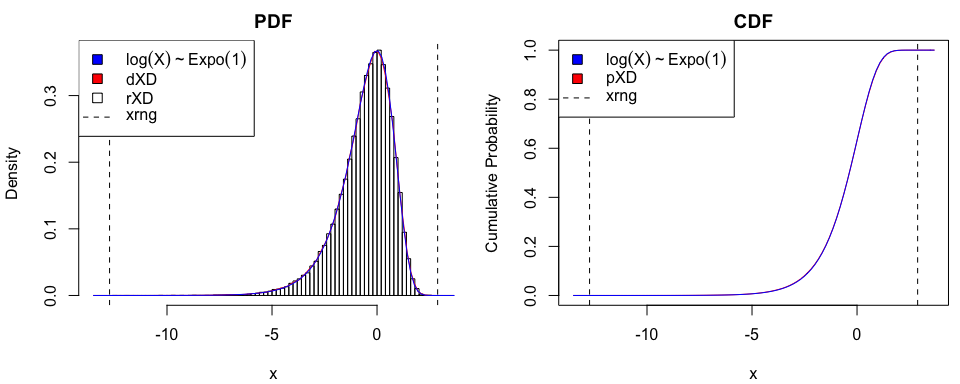

```r
dlexp <- function(x) exp(-exp(x) + x) # true PDF
plexp <- function(x) pexp(exp(x)) # true CDF
xdens_test(xDens, dtrue = dlexp, ptrue = plexp,
           dname = expression(log(X)%~%"Expo"*(1)),
           dlpos = "topleft", plpos = "topleft")
```

## Constructors

`xDens` objects can be constructed using three methods: two involving density estimation of random sample from $f(x)$, and one from a functional approximation to $f(x)$, e.g., using a parametric family $f(x \mid \hat {{\boldsymbol{\theta}}})$, where $\hat{{\boldsymbol{\theta}}}$ is the parameter MLE.

### Kernel Density Estimation

The `kernelXD` function uses the `density` function in **R** to fit a Gaussian kernel to a random sample from $f(x)$. It is the most flexible constructor, however it also requires the most datapoints for stable estimation. Below is a comparison with $M$ iid samples from a $\chi^2_{(4)}$ distribution, using $M = 1000$ and $M = 10000$ data points.

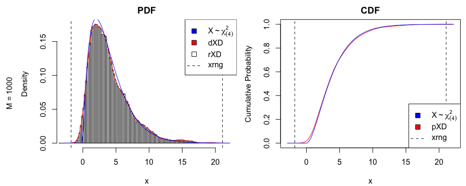

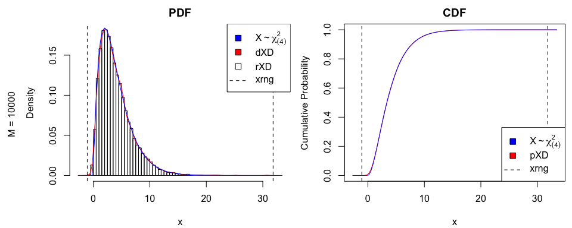

```r
# true distribution: chi^2_(4)
df_true <- 4
dtrue <- function(x) dchisq(x, df = df_true)
ptrue <- function(x) pchisq(x, df = df_true)
rtrue <- function(n) rchisq(n, df = df_true)
dname <- paste0("X%~%chi[(",df_true,")]^2")

# simulate data
nsamples <- 1e3
X <- rtrue(nsamples)
xDens <- kernelXD(X) # xDens constructor

par(oma = c(0,2,0,0)) # put sample size in outer margin
xdens_test(xDens, dtrue = dtrue, ptrue = ptrue,
           dname = dname,
           dlpos = "topright", plpos = "bottomright")
mtext(text = paste0("M = ", nsamples),
      side = 2, line = .5, outer = TRUE)

# increase sample size
nsamples <- 1e4
X <- rtrue(nsamples)
xDens <- kernelXD(X)
xdens_test(xDens, dtrue = dtrue, ptrue = ptrue,
           dname = dname,
           dlpos = "topright", plpos = "bottomright")
mtext(text = paste0("M = ", nsamples),
      side = 2, line = .5, outer = TRUE)
par(oma = c(0,0,0,0)) # remove outer margin
```

### Gram-Charlier Expansion

The `gc4XD` constructor is a moment-based density estimator, ideal for unimodal distributions to be estimated from small sample sizes. The estimator first applies a Box-Cox transformation to the data, then fits it with a 4th order [Gram-Charlier expansion](https://en.wikipedia.org/wiki/Edgeworth_series) (e.g., Draper and Tierney 1972). The example below illustrates the approximation for $M = 1000$ observations of $X \sim \chi^2_{(4)}$.

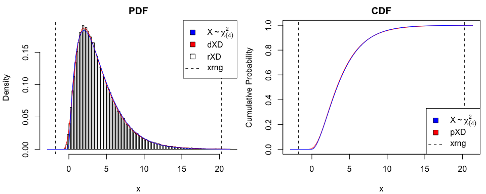

```r
nsamples <- 1e3
X <- rtrue(nsamples)
xDens <- gc4XD(X) # xDens constructor
xdens_test(xDens, dtrue = dtrue, ptrue = ptrue,
           dname = dname,
           dlpos = "topright", plpos = "bottomright")
```

### Known Density Values

The `matrixXD` is used to convert functional density representations into the standardized `xDens` format. Its input is a 2-column matrix with equally-spaced $x$-grid values in the first column and corresponding density values in the second. Below is an illustration using the Cauchy distribution.

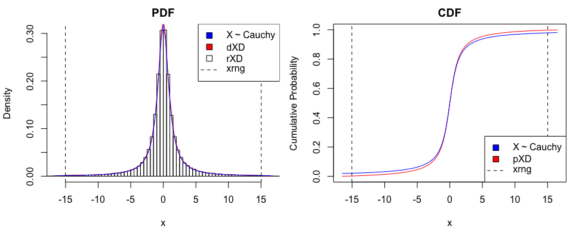

```r
# true distribution: Cauchy
dtrue <- function(x) dcauchy(x)
ptrue <- function(x) pcauchy(x)
dname <- expression(X%~%"Cauchy")

# matrix density representation
xgrid <- seq(from=-15, to=15, len = 500) # grid
ypdf <- dtrue(xgrid)
xDens <- matrixXD(cbind(X = xgrid, Y = ypdf)) # xDens constructor

xdens_test(xDens, dtrue = dtrue, ptrue = ptrue,
           dname = dname,
           dlpos = "topright", plpos = "bottomright")
```

## Appendix A: Endpoint Matching

We wish to find the parameters $(\mu, \sigma)$ of a normal distribution whose PDF passes through the points $(x_i, y_i)$, $i = 1,2$. Thus we wish to find $(\mu, \sigma)$ satisfying
$$\log y_i = -\frac 1 2 \left[\frac{(x_i - \mu)^2}{\sigma^2} + \log \sigma^2 + \log 2\pi \right], \qquad i = 1,2.$$
Subtracting one equation from the other, we obtain
$$\log(y_1/y_2) = \frac{(x_1 - \mu)^2}{2\sigma^2} - \frac{(x_2 - \mu)^2}{2\sigma^2},$$
such that for any value of $\sigma$ the required value of $\mu$ is
$$\mu(\sigma) = \sigma^2\frac{\log(y_1/y_2)}{x_1 - x_2} + \frac{x_1 + x_2}{2} = b \sigma^2 + a.$$
Substituting this back into one of the two original equations leads to the root-finding problem
$$g(\tau) = \frac{A^2}{\tau} + B^2 \tau + \log \tau - C = 0,$$
where $\tau = \sigma^2$ and
$$A = x_i - a, \qquad B = b, \qquad C = 2[b(x_i-a) - \log y_i] - \log 2\pi.$$
A solution to this equation is not guaranteed to exist. For instance, let $x_1 = -1$, $x_2 = 1$, and $y_i = 1$. Then a Normal distribution passing through these points must have density at least $2$. However, in our case $y_i$ will typically be very small, in which case a root is likely to exist. Even then, there could be two roots to the equation: one with $\mu$ between $x_1$ and $x_2$, and one with $\mu$ (way) off to one side. We’ll focus here on finding the former.

The root we seek can be calculated numerically with the (built-in) **R** function `uniroot`, which requires specification of an interval containing the root. To obtain this interval, first notice that $g'(\tau) = -\frac{A^2}{\tau^2} + B^2 + \frac{1}{\tau}$, of which the only positive solution is
$$\tau_L = \frac{-1 + \sqrt{1 + 4(AB)^2}}{2B^2}.$$
Since $g(\tau) \to \infty$ for $\tau \to 0$ and $\tau \to \infty$, we conclude that $\tau_L$ is the minimum value of $g(\tau)$ on $\tau \in (0,\infty)$. Let us now find a value $\tau_U < \tau_L$ at which $g(\tau_U) > 0$ (doing this for $\tau_U > \tau_L$ is likely to have $\mu$ outside of $(x_1, x_2)$).

In order to find a lower bound for the root, note that for $0 < \tau < A^2/2$, we have
$$\log \tau > -\frac{A^2/2}{\tau} + D, \qquad D = 1 + \log(A^2/2).$$
This is because the derivative of the RHS is larger than that of the LHS for $\tau < A^2/2$, thus falls to $-\infty$ monotonically faster as $\tau \to 0$. The value of $D$ is chosen such that LHS and RHS are equal at $\tau = A^2/2$. Substituting the inequality above into the root-finding equation, we obtain
$$g(\tau) > \frac{A^2}{\tau} + \log \tau - C > \frac{A^2/2}{\tau} + D - C,$$
such that $g(\tau) > 0$ for $\tau < \frac{A^2}{2(C-D)}$.

Note that when $y_1 = y_2$, the endpoint matching method breaks down and the mean and standard deviation of the approximated density is used for the Normally distributed tails.

## References

Draper, N.R. and Tierney, D.E., 1972. Regions of positive and unimodal series expansion of the Edgeworth and Gram-Charlier approximations. *Biometrika*, 59 (2), 463–465.

Hofert, M., Kojadinovic, I., Maechler, M., and Yan, J., 2017. *Copula: Multivariate dependence with copulas*.

Schepsmeier, U., Stoeber, J., Brechmann, E.C., Graeler, B., Nagler, T., and Erhardt, T., 2017. *VineCopula: Statistical inference of vine copulas*.